# Algae-Casestudies

Habui

Thursday, October 08, 2015

# Step 0: Prepare for analysis

```r
library('DMwR')
library('cluster')
library('rpart')
data(algae)
```

# Step 1: Examine the dataset

The idea is to calculate the missing value based on values of similar rows. Similar could be calculated in several metrics; the most familar, well-known is Euclidean.

```r
summary(algae)
```

```
##     season       size       speed         mxPH            mnO2
##  autumn:40   large :45   high  :84   Min.   :5.600   Min.   : 1.500
##  spring:53   medium:84   low   :33   1st Qu.:7.700   1st Qu.: 7.725
##  summer:45   small :71   medium:83   Median :8.060   Median : 9.800
##  winter:62                           Mean   :8.012   Mean   : 9.118
##                                      3rd Qu.:8.400   3rd Qu.:10.800
##                                      Max.   :9.700   Max.   :13.400
##                                      NA's   :1       NA's   :2
##        Cl               NO3              NH4                oPO4
##  Min.   :  0.222   Min.   : 0.050   Min.   :    5.00   Min.   :  1.00
##  1st Qu.: 10.981   1st Qu.: 1.296   1st Qu.:   38.33   1st Qu.: 15.70
##  Median : 32.730   Median : 2.675   Median :  103.17   Median : 40.15
##  Mean   : 43.636   Mean   : 3.282   Mean   :  501.30   Mean   : 73.59
##  3rd Qu.: 57.824   3rd Qu.: 4.446   3rd Qu.:  226.95   3rd Qu.: 99.33
##  Max.   :391.500   Max.   :45.650   Max.   :24064.00   Max.   :564.60
##  NA's   :10        NA's   :2        NA's   :2          NA's   :2
##       PO4              Chla               a1              a2
##  Min.   :  1.00   Min.   :  0.200   Min.   : 0.00   Min.   : 0.000
##  1st Qu.: 41.38   1st Qu.:  2.000   1st Qu.: 1.50   1st Qu.: 0.000
##  Median :103.29   Median :  5.475   Median : 6.95   Median : 3.000
##  Mean   :137.88   Mean   : 13.971   Mean   :16.92   Mean   : 7.458
##  3rd Qu.:213.75   3rd Qu.: 18.308   3rd Qu.:24.80   3rd Qu.:11.375
##  Max.   :771.60   Max.   :110.456   Max.   :89.80   Max.   :72.600
##  NA's   :2        NA's   :12
##        a3               a4               a5               a6
##  Min.   : 0.000   Min.   : 0.000   Min.   : 0.000   Min.   : 0.000
##  1st Qu.: 0.000   1st Qu.: 0.000   1st Qu.: 0.000   1st Qu.: 0.000
##  Median : 1.550   Median : 0.000   Median : 1.900   Median : 0.000
##  Mean   : 4.309   Mean   : 1.992   Mean   : 5.064   Mean   : 5.964
##  3rd Qu.: 4.925   3rd Qu.: 2.400   3rd Qu.: 7.500   3rd Qu.: 6.925
##  Max.   :42.800   Max.   :44.600   Max.   :44.400   Max.   :77.600
##
##        a7
##  Min.   : 0.000
##  1st Qu.: 0.000
##  Median : 1.000
##  Mean   : 2.495
##  3rd Qu.: 2.400
##  Max.   :31.600
##
```

A picture worths a thoundsand words. Besides, `summary`, we could plot the dataset to observer its distributions. For example, the plot of `mxPH` could be obtained by:

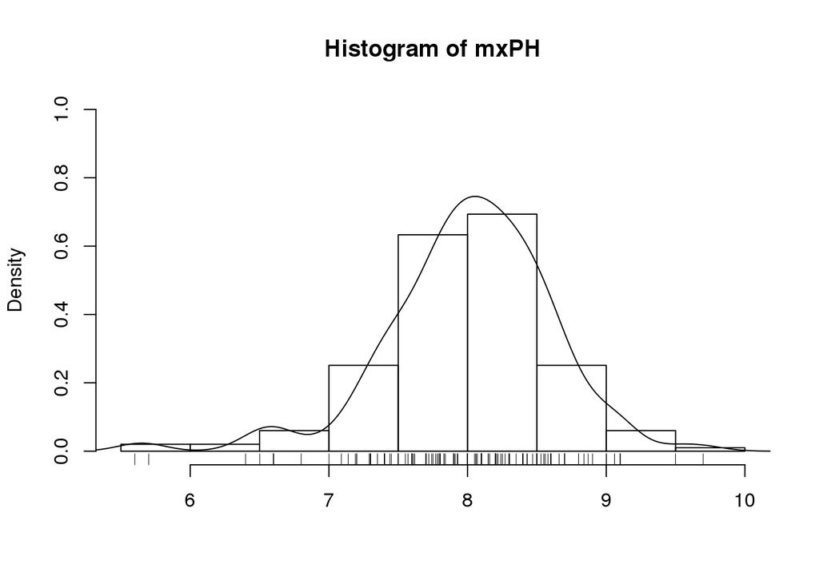

```r
hist(algae$mxPH, prob=T, xlab='', main='Histogram of mxPH', ylim=0:1)
lines(density(algae$mxPH, na.rm=T))
rug(jitter(algae$mxPH))
```

# Step 2: Clean up the data. Process unknown values

## 1. Removing observations with too many unknown values

```r
# Remove rows with too many NAs
algae <- algae[-c(62, 199),]
```

## 2. Filling the unknowns with the most frequent values

```r
algae[48, 'mxPH'] <- mean(algae$mxPH, na.rm=T)
```

Though, this method is sometime dangerous, and should be done in cautious. For example, the distribution is skewed to higher values, and there are few extreme values that make the mean value highly unrepresentative of the most frequent value.

```r
# Unlikely reasonable
algae[is.na(algae$Chla), 'Chla'] <- mean(algae$Chla, na.rm=T)
```

## 3. Filling the unknowns by exploring correlations

We could find the correlation between variables using function `cor`

```r
symnum(cor(algae[,4:18], use='complete.obs'))
```

```
##      mP mO Cl NO NH o P Ch a1 a2 a3 a4 a5 a6 a7
## mxPH 1
## mnO2    1
## Cl         1
## NO3           1
## NH4           ,  1
## oPO4    .  .        1
## PO4     .  .        * 1
## Chla .                  1
## a1         .        . .    1
## a2   .                  .     1
## a3                               1
## a4      .           . .             1
## a5                                     1
## a6            .  .                     .  1
## a7                                           1
## attr(,"legend")
## [1] 0 ' ' 0.3 '.' 0.6 ',' 0.8 '+' 0.9 '*' 0.95 'B' 1
```

We exclude three first column because they are normial. The use of `use='complete.obs'` tell R to obmit `NAs` from the calculation of correlation.

We can observe that the correlations are most of the time irrelevant. However there are 2 exceptions: NH4 and NO3 and oPO4 and PO4.

We could use linear regression to fill the correlation

```r
lm(oPO4 ~ PO4, data=algae)
```

```
##
## Call:
## lm(formula = oPO4 ~ PO4, data = algae)
##
## Coefficients:
## (Intercept)          PO4
##    -15.6142       0.6466
```

```r
fillPO4 <- function(o) {
  if (is.na(o)) return(NA)
  return((o+15.6142)/0.6466)
}

algae[is.na(algae$Chla), 'Chla'] <- median(algae$Chla,na.rm=T)
algae[is.na(algae$PO4), 'PO4'] <- sapply(algae[is.na(algae$PO4), 'oPO4'], fillPO4)
```

## 4. Filling the unknowns by exploring similarities between cases.

```r
data(algae)
algae <- algae[-c(62, 199),]
central.value <- function(x) {
  if (is.numeric(x)) median(x, na.rm=T)
  else if(is.factor(x)) levels(x)[which.max(table(x))]
  else {
    f <- as.factor(x)
    levels(f)[which.max(table(f))]
  }
}


dist.mtx <- as.matrix(daisy(algae,stand=T))
for(r in which(!complete.cases(algae))) {
  algae[r, which(is.na(algae[r,]))] <-
    apply(data.frame(algae[c(as.integer(names(sort(dist.mtx[r,])[2:11]))),
                     which(is.na(algae[r,]))]),
          2, central.value)
}

# Save the clean data at clean.algae
clean.algae <- algae
data(algae)
```

# Step 3: Prediction models

we will explore 2 preditive models that can be applied in algae domain: * Linear Regression * Regression Tree

## Multiple linear regression

We could obtain linear regression model using function `lm`

```r
lm.a1 <- lm(a1 ~ ., data = clean.algae[,1:12])
lm.a1 <- step(lm.a1)
```

```
## Start:  AIC=1151.92
## a1 ~ season + size + speed + mxPH + mnO2 + Cl + NO3 + NH4 + oPO4 +
##     PO4 + Chla
##
##          Df Sum of Sq   RSS    AIC
## - season  3    426.17 57064 1147.4
## - speed   2    269.07 56907 1148.9
## - oPO4    1      5.33 56643 1149.9
## - Chla    1    395.42 57034 1151.3
## - Cl      1    482.83 57121 1151.6
## - mxPH    1    536.22 57174 1151.8
## <none>                56638 1151.9
## - mnO2    1    651.01 57289 1152.2
## - NH4     1    803.05 57441 1152.7
## - PO4     1    900.79 57539 1153.0
## - size    2   1874.20 58512 1154.4
## - NO3     1   2291.38 58930 1157.8
##
## Step:  AIC=1147.41
## a1 ~ size + speed + mxPH + mnO2 + Cl + NO3 + NH4 + oPO4 + PO4 +
##     Chla
##
##         Df Sum of Sq   RSS    AIC
## - speed  2    212.35 57277 1144.1
## - oPO4   1      7.42 57072 1145.4
## - Chla   1    372.32 57437 1146.7
## - mnO2   1    427.75 57492 1146.9
## - Cl     1    448.53 57513 1147.0
## - mxPH   1    452.98 57517 1147.0
## <none>               57064 1147.4
## - NH4    1    754.92 57819 1148.0
## - PO4    1    861.18 57925 1148.4
## - size   2   2187.58 59252 1150.8
## - NO3    1   2359.61 59424 1153.4
##
## Step:  AIC=1144.14
## a1 ~ size + mxPH + mnO2 + Cl + NO3 + NH4 + oPO4 + PO4 + Chla
##
##        Df Sum of Sq   RSS    AIC
## - oPO4  1     16.09 57293 1142.2
```

[output cut: 44 more lines]

```
## - mxPH  1     830.3 58759 1141.2
## - size  2    2475.6 60405 1144.7
## - NO3   1    2231.3 60161 1145.9
## - PO4   1    9052.7 66982 1167.1
##
## Step:  AIC=1140.17
## a1 ~ size + mxPH + Cl + NO3 + PO4
##
##        Df Sum of Sq   RSS    AIC
## <none>              58453 1140.2
## - mxPH  1     795.9 59249 1140.8
## - Cl    1     884.6 59338 1141.1
## - NO3   1    1976.0 60429 1144.8
## - size  2    2659.6 61113 1145.0
## - PO4   1    8536.8 66990 1165.2
```

```r
summary(lm.a1)
```

```
##
## Call:
## lm(formula = a1 ~ size + mxPH + Cl + NO3 + PO4, data = clean.algae[,
##     1:12])
##
## Residuals:
##     Min      1Q  Median      3Q     Max
## -28.877 -12.694  -3.703   8.405  62.889
##
## Coefficients:
##             Estimate Std. Error t value Pr(>|t|)
## (Intercept) 57.52377   20.94216   2.747  0.00659 **
## sizemedium   2.82815    3.40016   0.832  0.40658
## sizesmall   10.40727    3.81850   2.725  0.00702 **
## mxPH        -3.99789    2.47903  -1.613  0.10846
## Cl          -0.05377    0.03163  -1.700  0.09074 .
## NO3         -0.89280    0.35135  -2.541  0.01185 *
## PO4         -0.05896    0.01116  -5.282 3.47e-07 ***
## ---
## Signif. codes:  0 '***' 0.001 '**' 0.01 '*' 0.05 '.' 0.1 ' ' 1
##
## Residual standard error: 17.49 on 191 degrees of freedom
## Multiple R-squared:  0.3534, Adjusted R-squared:  0.3331
## F-statistic:  17.4 on 6 and 191 DF,  p-value: 5.022e-16
```

R handles normial variables by creating a set of auxiliary variables. Namely for each factors with k levels, R create k-1 auxiliary variables. The variables have the values 0 or 1. A value of 1 means the associated value of the factor is “present”, and that will mean that other auxiliary variables have value 0.

**summary** function gives some **diagnostic information** including: * The residuals of the fit of the linear model and the used data. * For each coefficients, R will show its value and standard errors, as well as the importance of each coefficient. * Proportion of explained variance. * F-statistic

We should spend time here explaining a little bit the meaning of “The importance of each coefficient”. The importance of a variable represents its influences on the final result. It is measured by “the null hypothesis”, which test the valid of the statement: `H0: a variable is null`. In order to accept or reject the hypothesis, we conduct a t-student test.

## Regression Trees

We can obtain regression tree using the following commands:

```r
library(rpart)
data(algae)
algae <- algae[-c(62, 199),]
rt.a1 <- rpart(a1 ~ ., data = algae[,1:12])
```

The function `rpart` stop growing the trees when certain criteria are met * The decrease in the deviance goes below a certain threshold * The number of samples in the node is less than another threshold * The tree depth exceeds another value.

The thresholds are controlled by the parameters: *cp*, *minsplit*, *maxdepth*. Their default values are 0.01, 20, and 30 respectively.

we should always check the validity of these default tree growth stopping criteria to prevent overfitting data. This can be carried out through a process of post-pruning of the obtained tree. The rpart package implements a pruning method named *cost complexity* pruning. This method tries to estimate the value of *cp* that ensues the best compromise between their predictive accuracy and tree size.

Given a tree produced by *rpart()*, R can produced a set of sub-trees of this tree and estimate their predictive performance. This information can be obtained using the function *printcp()*.

```r
reliable.rpart <- function(form,data, se = 1,cp = 0,verbose=T, ...) {
  tree <- rpart(form, data, cp=cp, ...)
  if (verbose && ncol(tree$cptable) < 5) tree
  else {
    lin.min.err <- which.min(tree$cptable[, 4])
    if (verbose && lin.min.err == nrow(tree$cptable))
      warning("Minimal cross Validation Error is obtained with the largest tree\n. Further tree growth could produce more accurate tree\n")
    tol.err <- tree$cptable[lin.min.err, 4] + se * tree$cptable[lin.min.err, 5]
    se.lin <- which(tree$cptable[,4] <= tol.err)[1]
    prune.rpart(tree, cp=tree$cptable[se.lin, 1]+1e-9)
  }
}

rt.a1 <- reliable.rpart(a1 ~ ., data=algae[,1:12])
```

# Step 4: Model evaluation and Selection

To obtain the prediction of any R model, one uses the function **predict()**.

```r
lm.prediction.a1 <- predict(lm.a1, data=clean.algae)
rt.prediction.a1 <- predict(rt.a1, data=algae)
```

#### Mean Absolute Error:

```r
(mae.a1.lm <- mean(abs(lm.prediction.a1 - clean.algae[,'a1'])))
```

```
## [1] 13.10378
```

```r
(mae.a1.rt <- mean(abs(rt.prediction.a1 - algae[,'a1'])))
```

```
## [1] 11.61717
```

#### Mean Squared Error

```r
(mse.a1.lm <- mean((lm.prediction.a1 - clean.algae[,'a1'])^2))
```

```
## [1] 295.217
```

```r
(mse.a1.rt <- mean((rt.prediction.a1 - algae[,'a1'])^2))
```

```
## [1] 271.3226
```

#### Normalized Mean Squared Error

```r
(nmse.a1.lm <- mean((lm.prediction.a1 - clean.algae[,'a1'])^2) / mean((mean(clean.algae[,'a1']) - clean.algae[,'a1'])^2))
```

```
## [1] 0.6465945
```

```r
(nmse.a1.rt <- mean((rt.prediction.a1 - algae[,'a1'])^2) / mean((mean(algae[,'a1']) - algae[,'a1'])^2))
```

```
## [1] 0.5942601
```

The smaller NMSE, the better.

#### Visual inspection of the prediction

The idea is to plot the whole prediction and obserse their result under the line with angle **pi/4**.

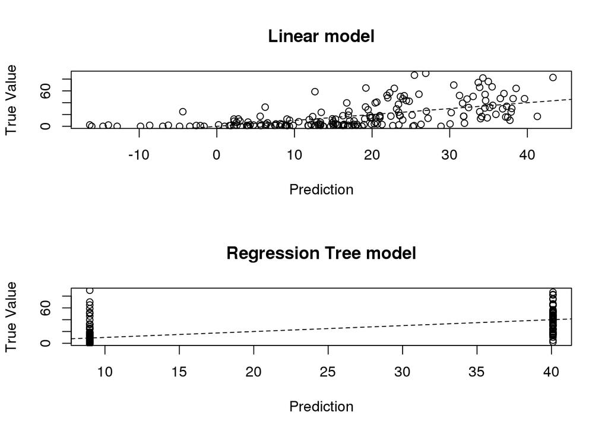

```r
old.par <- par(mfrow=c(2,1))
plot(lm.prediction.a1, clean.algae[, 'a1'], main="Linear model", xlab="Prediction", ylab="True Value")
abline(0, 1, lty=2)
plot(rt.prediction.a1, algae[, 'a1'], main="Regression Tree model", xlab="Prediction", ylab="True Value")
abline(0, 1, lty=2)
```

```r
par(old.par)
```

Several criteria exists for evaluating models. Among the most popular are criteria that calculate the **predictive performance of models**. The predictive performances of models is obtained by comparing the prediction of models with the real values of the target variables.

The key issue here is to obtain a reliable estimate of a model performance on data for which we do not know the true target value. The measures calculated using the training data are unreliable, because they are biased. In effect, there are models that can easily obtain zero prediction error on the training data, however, this performance will hardly generalize over new samples for which the target variable value is unknown. This phenomenon is usually known as *overfitting*.

*K-fold Cross Validation* is among the most frequently used methods of obtaining these reliable estimates for small data sets like our case study. The idea is: otain `K` equally sized and randomized sub-sets of training data. For each of these `K` subsets, build a model using the remaining K-1 sets and evaluate this model on the Kth subset. Store the performance of the model and repeat this process for all remaining subsets. In the end, we have K performance measures, all obtained by testing a model on data not used for its construction. The K-fold Cross Validation estimation is the average of these K measures. A common choice for K is 10.

```
## Fold  1
## Start:  AIC=1049.17
## a1 ~ season + size + speed + mxPH + mnO2 + Cl + NO3 + NH4 + oPO4 +
##     PO4 + Chla
##
##          Df Sum of Sq   RSS    AIC
## - season  3    199.70 52771 1043.8
## - speed   2    288.57 52860 1046.2
## - oPO4    1      7.14 52579 1047.2
## - Cl      1    255.35 52827 1048.0
## - Chla    1    340.72 52912 1048.3
## - mnO2    1    490.53 53062 1048.8
## - mxPH    1    583.94 53155 1049.2
## <none>                52571 1049.2
## - PO4     1    834.52 53406 1050.0
## - NH4     1    954.19 53526 1050.4
## - size    2   2034.63 54606 1052.0
## - NO3     1   2646.86 55218 1056.0
##
## Step:  AIC=1043.85
## a1 ~ size + speed + mxPH + mnO2 + Cl + NO3 + NH4 + oPO4 + PO4 +
##     Chla
##
##         Df Sum of Sq   RSS    AIC
## - speed  2    276.56 53048 1040.8
## - oPO4   1      5.66 52777 1041.9
## - Cl     1    259.22 53030 1042.7
## - Chla   1    321.35 53092 1042.9
## - mnO2   1    346.20 53117 1043.0
## - mxPH   1    580.88 53352 1043.8
## <none>               52771 1043.8
## - PO4    1    827.51 53599 1044.6
## - NH4    1    905.23 53676 1044.9
## - size   2   2248.43 55020 1047.3
## - NO3    1   2720.82 55492 1050.8
##
## Step:  AIC=1040.79
## a1 ~ size + mxPH + mnO2 + Cl + NO3 + NH4 + oPO4 + PO4 + Chla
##
##        Df Sum of Sq   RSS    AIC
```

[output cut: 45 more lines]

```
## - NH4   1    1172.4 54706 1038.3
## - size  2    2473.3 56007 1040.5
## - NO3   1    3888.7 57422 1047.0
## - PO4   1    8142.0 61676 1059.8
##
## Step:  AIC=1036
## a1 ~ size + mxPH + NO3 + NH4 + PO4
##
##        Df Sum of Sq   RSS    AIC
## <none>              54008 1036.0
## - NH4   1     924.0 54932 1037.0
## - mxPH  1    1071.1 55080 1037.5
## - size  2    2815.6 56824 1041.1
## - NO3   1    3431.1 57440 1045.0
## - PO4   1   13350.4 67359 1073.5
```

```
## Fold  2
## Start:  AIC=1025.29
## a1 ~ season + size + speed + mxPH + mnO2 + Cl + NO3 + NH4 + oPO4 +
##     PO4 + Chla
##
##          Df Sum of Sq   RSS    AIC
## - season  3    107.96 46112 1019.7
## - speed   2    252.98 46257 1022.3
## - oPO4    1     42.00 46046 1023.5
## - Chla    1    175.23 46179 1024.0
## - mnO2    1    178.84 46183 1024.0
## - size    2    720.06 46724 1024.1
## - Cl      1    202.12 46206 1024.1
## - mxPH    1    490.21 46494 1025.2
## <none>                46004 1025.3
## - NH4     1    710.32 46714 1026.0
## - PO4     1   1186.43 47190 1027.8
## - NO3     1   2372.40 48376 1032.3
##
## Step:  AIC=1019.71
## a1 ~ size + speed + mxPH + mnO2 + Cl + NO3 + NH4 + oPO4 + PO4 +
##     Chla
##
##         Df Sum of Sq   RSS    AIC
## - speed  2    253.27 46365 1016.7
## - oPO4   1     28.03 46140 1017.8
## - Chla   1    179.03 46291 1018.4
## - mnO2   1    189.24 46301 1018.4
## - Cl     1    231.74 46344 1018.6
## - size   2    810.16 46922 1018.8
## - mxPH   1    433.62 46545 1019.4
## <none>               46112 1019.7
## - NH4    1    695.94 46808 1020.4
## - PO4    1   1126.94 47239 1022.0
## - NO3    1   2359.83 48472 1026.6
##
## Step:  AIC=1016.69
## a1 ~ size + mxPH + mnO2 + Cl + NO3 + NH4 + oPO4 + PO4 + Chla
##
##        Df Sum of Sq   RSS    AIC
```

[output cut: 45 more lines]

```
## - NH4   1     539.4 47315 1012.3
## - mxPH  1     620.9 47397 1012.6
## - NO3   1    2278.7 49055 1018.8
## - PO4   1    7923.6 54699 1038.3
##
## Step:  AIC=1011.91
## a1 ~ size + mxPH + NO3 + NH4 + PO4
##
##        Df Sum of Sq   RSS    AIC
## <none>              47207 1011.9
## - mxPH  1     651.4 47859 1012.4
## - NH4   1     692.1 47900 1012.5
## - size  2    1232.5 48440 1012.5
## - NO3   1    2773.2 49981 1020.1
## - PO4   1   12296.8 59504 1051.3
```

```
## Fold  3
## Start:  AIC=1038.43
## a1 ~ season + size + speed + mxPH + mnO2 + Cl + NO3 + NH4 + oPO4 +
##     PO4 + Chla
##
##          Df Sum of Sq   RSS    AIC
## - season  3    330.22 49838 1033.6
## - speed   2    276.00 49784 1035.4
## - oPO4    1     17.72 49526 1036.5
## - Chla    1    218.25 49726 1037.2
## - Cl      1    296.20 49804 1037.5
## - mnO2    1    498.91 50007 1038.2
## <none>                49508 1038.4
## - NH4     1    567.35 50075 1038.5
## - PO4     1    623.62 50132 1038.7
## - mxPH    1    644.50 50152 1038.7
## - size    2   1693.54 51201 1040.5
## - NO3     1   1708.42 51216 1042.5
##
## Step:  AIC=1033.62
## a1 ~ size + speed + mxPH + mnO2 + Cl + NO3 + NH4 + oPO4 + PO4 +
##     Chla
##
##         Df Sum of Sq   RSS    AIC
## - speed  2    247.34 50085 1030.5
## - oPO4   1     17.42 49856 1031.7
## - Chla   1    205.37 50043 1032.3
## - Cl     1    271.62 50110 1032.6
## - mnO2   1    295.21 50133 1032.7
## - NH4    1    508.68 50347 1033.4
## <none>               49838 1033.6
## - mxPH   1    594.80 50433 1033.7
## - PO4    1    617.33 50455 1033.8
## - size   2   1882.47 51721 1036.2
## - NO3    1   1757.94 51596 1037.8
##
## Step:  AIC=1030.5
## a1 ~ size + mxPH + mnO2 + Cl + NO3 + NH4 + oPO4 + PO4 + Chla
##
##        Df Sum of Sq   RSS    AIC
```

[output cut: 45 more lines]

```
## - mxPH  1     941.3 51447 1027.3
## - size  2    2034.3 52540 1029.1
## - NO3   1    1570.0 52075 1029.5
## - PO4   1    7553.8 58059 1049.0
##
## Step:  AIC=1025.08
## a1 ~ size + mxPH + Cl + NO3 + PO4
##
##        Df Sum of Sq   RSS    AIC
## <none>              50811 1025.1
## - Cl    1     609.9 51421 1025.2
## - mxPH  1     931.8 51743 1026.3
## - NO3   1    1552.1 52363 1028.5
## - size  2    2182.1 52993 1028.6
## - PO4   1    7249.8 58061 1047.0
```

```
## Fold  4
## Start:  AIC=1045.46
## a1 ~ season + size + speed + mxPH + mnO2 + Cl + NO3 + NH4 + oPO4 +
##     PO4 + Chla
##
##          Df Sum of Sq   RSS    AIC
## - speed   2    244.19 51737 1042.3
## - season  3    878.13 52371 1042.5
## - oPO4    1    114.05 51607 1043.9
## - mxPH    1    168.00 51661 1044.0
## - PO4     1    535.57 52028 1045.3
## <none>                51493 1045.5
## - Chla    1    584.89 52078 1045.5
## - Cl      1    695.33 52188 1045.9
## - mnO2    1    827.44 52320 1046.3
## - NH4     1    848.09 52341 1046.4
## - size    2   2576.21 54069 1050.2
## - NO3     1   2261.78 53754 1051.2
##
## Step:  AIC=1042.31
## a1 ~ season + size + mxPH + mnO2 + Cl + NO3 + NH4 + oPO4 + PO4 +
##     Chla
##
##          Df Sum of Sq   RSS    AIC
## - season  3    772.83 52510 1039.0
## - oPO4    1    152.69 51890 1040.8
## - mxPH    1    189.42 51926 1041.0
## - PO4     1    428.48 52165 1041.8
## - Chla    1    462.71 52200 1041.9
## <none>                51737 1042.3
## - Cl      1    660.99 52398 1042.6
## - mnO2    1    661.79 52399 1042.6
## - NH4     1    781.18 52518 1043.0
## - size    2   2335.62 54073 1046.2
## - NO3     1   2229.83 53967 1047.9
##
## Step:  AIC=1038.96
## a1 ~ size + mxPH + mnO2 + Cl + NO3 + NH4 + oPO4 + PO4 + Chla
##
##        Df Sum of Sq   RSS    AIC
```

[output cut: 45 more lines]

```
## - Cl    1     755.9 54009 1036.0
## - NO3   1    1814.7 55068 1039.5
## - size  2    4433.7 57687 1045.8
## - PO4   1    8539.6 61793 1060.1
##
## Step:  AIC=1035.2
## a1 ~ size + Cl + NO3 + PO4 + Chla
##
##        Df Sum of Sq   RSS    AIC
## <none>              53766 1035.2
## - Chla  1     672.0 54438 1035.4
## - Cl    1    1035.8 54802 1036.6
## - NO3   1    1483.4 55249 1038.1
## - size  2    4513.3 58279 1045.6
## - PO4   1    8035.8 61802 1058.1
```

```
## Fold  5
## Start:  AIC=1048.48
## a1 ~ season + size + speed + mxPH + mnO2 + Cl + NO3 + NH4 + oPO4 +
##     PO4 + Chla
##
##          Df Sum of Sq   RSS    AIC
## - season  3    488.49 52855 1044.1
## - speed   2    251.31 52618 1045.3
## - oPO4    1     29.41 52396 1046.6
## - Cl      1    477.94 52844 1048.1
## - Chla    1    523.95 52890 1048.3
## <none>                52366 1048.5
## - size    2   1191.21 53558 1048.5
## - PO4     1    625.87 52992 1048.6
## - mnO2    1    759.43 53126 1049.0
## - NH4     1    764.14 53130 1049.1
## - mxPH    1   1152.73 53519 1050.4
## - NO3     1   2084.74 54451 1053.5
##
## Step:  AIC=1044.14
## a1 ~ size + speed + mxPH + mnO2 + Cl + NO3 + NH4 + oPO4 + PO4 +
##     Chla
##
##         Df Sum of Sq   RSS    AIC
## - speed  2    187.01 53042 1040.8
## - oPO4   1     28.43 52883 1042.2
## - Cl     1    438.34 53293 1043.6
## - Chla   1    461.97 53317 1043.7
## - mnO2   1    494.13 53349 1043.8
## <none>               52855 1044.1
## - PO4    1    606.17 53461 1044.2
## - NH4    1    714.38 53569 1044.5
## - size   2   1437.74 54293 1044.9
## - mxPH   1   1061.45 53916 1045.7
## - NO3    1   2170.87 55026 1049.3
##
## Step:  AIC=1040.77
## a1 ~ size + mxPH + mnO2 + Cl + NO3 + NH4 + oPO4 + PO4 + Chla
##
##        Df Sum of Sq   RSS    AIC
```

[output cut: 45 more lines]

```
## - size  2    1642.7 55487 1038.8
## - mxPH  1    1628.2 55472 1040.8
## - NO3   1    2022.8 55867 1042.1
## - PO4   1    8144.0 61988 1060.7
##
## Step:  AIC=1036.95
## a1 ~ size + mxPH + Cl + NO3 + PO4
##
##        Df Sum of Sq   RSS    AIC
## <none>              54296 1037.0
## - Cl    1     912.0 55208 1037.9
## - size  2    1836.3 56132 1038.9
## - mxPH  1    1578.0 55874 1040.1
## - NO3   1    1886.7 56183 1041.1
## - PO4   1    7692.3 61988 1058.7
```

```
## Fold  6
## Start:  AIC=1051.51
## a1 ~ season + size + speed + mxPH + mnO2 + Cl + NO3 + NH4 + oPO4 +
##     PO4 + Chla
##
##          Df Sum of Sq   RSS    AIC
## - season  3    496.20 53758 1047.2
## - speed   2    322.27 53584 1048.6
## - oPO4    1      0.19 53262 1049.5
## - Chla    1    171.40 53433 1050.1
## - mnO2    1    382.19 53644 1050.8
## - NH4     1    559.67 53821 1051.4
## <none>                53261 1051.5
## - Cl      1    670.92 53932 1051.8
## - size    2   1387.00 54648 1052.1
## - mxPH    1    882.51 54144 1052.5
## - PO4     1   1062.65 54324 1053.0
## - NO3     1   1851.26 55113 1055.6
##
## Step:  AIC=1047.17
## a1 ~ size + speed + mxPH + mnO2 + Cl + NO3 + NH4 + oPO4 + PO4 +
##     Chla
##
##         Df Sum of Sq   RSS    AIC
## - speed  2    268.04 54026 1044.1
## - oPO4   1      0.17 53758 1045.2
## - Chla   1    159.57 53917 1045.7
## - mnO2   1    285.88 54043 1046.1
## - NH4    1    543.48 54301 1047.0
## <none>               53758 1047.2
## - Cl     1    695.40 54453 1047.5
## - mxPH   1    724.17 54482 1047.6
## - PO4    1    985.56 54743 1048.4
## - size   2   1751.00 55509 1048.9
## - NO3    1   1846.55 55604 1051.2
##
## Step:  AIC=1044.06
## a1 ~ size + mxPH + mnO2 + Cl + NO3 + NH4 + oPO4 + PO4 + Chla
##
##        Df Sum of Sq   RSS    AIC
```

[output cut: 45 more lines]

```
## - mxPH  1    1041.7 55379 1040.5
## - size  2    1756.0 56093 1040.8
## - NO3   1    1778.4 56115 1042.8
## - PO4   1    6754.7 61092 1058.1
##
## Step:  AIC=1038.37
## a1 ~ size + mxPH + Cl + NO3 + PO4
##
##        Df Sum of Sq   RSS    AIC
## <none>              54728 1038.4
## - mxPH  1     954.4 55682 1039.5
## - Cl    1    1213.0 55941 1040.3
## - size  2    1841.7 56569 1040.3
## - NO3   1    1845.0 56573 1042.3
## - PO4   1    6543.4 61271 1056.6
```

```
## Fold  7
## Start:  AIC=1037.51
## a1 ~ season + size + speed + mxPH + mnO2 + Cl + NO3 + NH4 + oPO4 +
##     PO4 + Chla
##
##          Df Sum of Sq   RSS    AIC
## - speed   2    171.93 49427 1034.1
## - season  3    847.90 50103 1034.6
## - oPO4    1     28.94 49284 1035.6
## - mxPH    1    192.94 49448 1036.2
## - Chla    1    260.52 49516 1036.5
## <none>                49255 1037.5
## - Cl      1    590.36 49846 1037.6
## - NH4     1    658.70 49914 1037.9
## - mnO2    1    921.51 50177 1038.8
## - PO4     1   1186.52 50442 1039.8
## - size    2   2025.20 51280 1040.7
## - NO3     1   1818.76 51074 1042.0
##
## Step:  AIC=1034.14
## a1 ~ season + size + mxPH + mnO2 + Cl + NO3 + NH4 + oPO4 + PO4 +
##     Chla
##
##          Df Sum of Sq   RSS    AIC
## - season  3    731.68 50159 1030.8
## - oPO4    1     12.61 49440 1032.2
## - Chla    1    193.94 49621 1032.8
## - mxPH    1    215.06 49642 1032.9
## - Cl      1    536.09 49963 1034.1
## <none>                49427 1034.1
## - NH4     1    627.65 50055 1034.4
## - mnO2    1    782.32 50210 1035.0
## - PO4     1   1059.58 50487 1035.9
## - size    2   1858.47 51286 1036.7
## - NO3     1   1820.31 51247 1038.6
##
## Step:  AIC=1030.77
## a1 ~ size + mxPH + mnO2 + Cl + NO3 + NH4 + oPO4 + PO4 + Chla
##
##        Df Sum of Sq   RSS    AIC
```

[output cut: 55 more lines]

```
## <none>              51204 1026.5
## - Cl    1     604.4 51808 1026.6
## - NO3   1    1572.2 52776 1029.9
## - size  2    4860.5 56064 1038.7
## - PO4   1    8203.6 59407 1051.1
##
## Step:  AIC=1025.87
## a1 ~ size + Cl + NO3 + PO4
##
##        Df Sum of Sq   RSS    AIC
## <none>              51610 1025.9
## - Cl    1     826.9 52437 1026.7
## - NO3   1    1337.7 52948 1028.5
## - size  2    5153.9 56764 1038.9
## - PO4   1    7799.6 59410 1049.1
```

```
## Fold  8
## Start:  AIC=1037.46
## a1 ~ season + size + speed + mxPH + mnO2 + Cl + NO3 + NH4 + oPO4 +
##     PO4 + Chla
##
##          Df Sum of Sq   RSS    AIC
## - season  3    399.18 49641 1032.9
## - speed   2    244.07 49486 1034.3
## - oPO4    1     12.03 49254 1035.5
## - mxPH    1    130.22 49372 1035.9
## - Cl      1    310.21 49552 1036.6
## - Chla    1    525.58 49767 1037.4
## <none>                49242 1037.5
## - mnO2    1    591.04 49833 1037.6
## - PO4     1    905.13 50147 1038.7
## - NH4     1   1255.28 50497 1040.0
## - size    2   2155.51 51397 1041.1
## - NO3     1   2224.88 51467 1043.4
##
## Step:  AIC=1032.91
## a1 ~ size + speed + mxPH + mnO2 + Cl + NO3 + NH4 + oPO4 + PO4 +
##     Chla
##
##         Df Sum of Sq   RSS    AIC
## - speed  2    217.39 49858 1029.7
## - oPO4   1     12.65 49654 1031.0
## - mxPH   1     70.76 49712 1031.2
## - Cl     1    294.95 49936 1032.0
## - mnO2   1    403.43 50045 1032.4
## - Chla   1    512.44 50154 1032.8
## <none>               49641 1032.9
## - PO4    1    858.21 50499 1034.0
## - NH4    1   1195.20 50836 1035.2
## - size   2   2458.59 52100 1037.6
## - NO3    1   2288.91 51930 1039.0
##
## Step:  AIC=1029.69
## a1 ~ size + mxPH + mnO2 + Cl + NO3 + NH4 + oPO4 + PO4 + Chla
##
##        Df Sum of Sq   RSS    AIC
```

[output cut: 45 more lines]

```
## - NH4   1     895.8 51260 1026.7
## - NO3   1    1846.3 52210 1029.9
## - size  2    3548.7 53913 1033.7
## - PO4   1    8733.7 59098 1052.1
##
## Step:  AIC=1025.41
## a1 ~ size + NO3 + NH4 + PO4 + Chla
##
##        Df Sum of Sq   RSS    AIC
## <none>              50906 1025.4
## - Chla  1     594.3 51500 1025.5
## - NH4   1    1296.0 52202 1027.9
## - NO3   1    2601.9 53508 1032.3
## - size  2    4181.9 55088 1035.5
## - PO4   1   13321.6 64227 1065.0
```

```
## Fold  9
## Start:  AIC=1039.36
## a1 ~ season + size + speed + mxPH + mnO2 + Cl + NO3 + NH4 + oPO4 +
##     PO4 + Chla
##
##          Df Sum of Sq   RSS    AIC
## - season  3    585.14 50350 1035.5
## - speed   2    449.62 50215 1037.0
## - NH4     1     18.42 49784 1037.4
## - oPO4    1     78.21 49843 1037.6
## - PO4     1    166.87 49932 1038.0
## <none>                49765 1039.4
## - Cl      1    581.54 50347 1039.4
## - Chla    1    625.52 50391 1039.6
## - mnO2    1    635.98 50401 1039.6
## - mxPH    1    712.77 50478 1039.9
## - size    2   2077.49 51843 1042.7
## - NO3     1   2235.27 52000 1045.2
##
## Step:  AIC=1035.45
## a1 ~ size + speed + mxPH + mnO2 + Cl + NO3 + NH4 + oPO4 + PO4 +
##     Chla
##
##         Df Sum of Sq   RSS    AIC
## - speed  2    312.48 50663 1032.6
## - NH4    1     34.87 50385 1033.6
## - oPO4   1    103.83 50454 1033.8
## - PO4    1    127.44 50478 1033.9
## - mnO2   1    402.11 50752 1034.9
## - Cl     1    518.85 50869 1035.3
## - mxPH   1    542.22 50893 1035.4
## <none>               50350 1035.5
## - Chla   1    641.40 50992 1035.7
## - size   2   2509.22 52860 1040.2
## - NO3    1   2380.40 52731 1041.7
##
## Step:  AIC=1032.56
## a1 ~ size + mxPH + mnO2 + Cl + NO3 + NH4 + oPO4 + PO4 + Chla
##
##        Df Sum of Sq   RSS    AIC
```

[output cut: 45 more lines]

```
## - Chla  1     879.8 52185 1029.9
## - size  2    2522.1 53828 1033.4
## - NO3   1    2276.5 53582 1034.6
## - oPO4  1    4239.1 55545 1041.0
##
## Step:  AIC=1028.53
## a1 ~ size + Cl + NO3 + oPO4 + Chla
##
##        Df Sum of Sq   RSS    AIC
## <none>              51799 1028.5
## - Cl    1     894.0 52693 1029.6
## - Chla  1    1590.6 53390 1031.9
## - NO3   1    1932.6 53732 1033.1
## - size  2    4027.0 55826 1037.9
## - oPO4  1    4702.7 56502 1042.1
```

```
## Fold  10
## Start:  AIC=1054.61
## a1 ~ season + size + speed + mxPH + mnO2 + Cl + NO3 + NH4 + oPO4 +
##     PO4 + Chla
##
##          Df Sum of Sq   RSS    AIC
## - season  3    482.16 54673 1050.2
## - speed   2    538.00 54729 1052.4
## - oPO4    1     32.53 54224 1052.7
## - Chla    1    404.18 54596 1053.9
## - mxPH    1    454.04 54645 1054.1
## - Cl      1    549.11 54740 1054.4
## <none>                54191 1054.6
## - PO4     1    611.00 54802 1054.6
## - NH4     1    824.54 55016 1055.3
## - mnO2    1    841.85 55033 1055.4
## - size    2   1469.61 55661 1055.4
## - NO3     1   2209.76 56401 1059.8
##
## Step:  AIC=1050.19
## a1 ~ size + speed + mxPH + mnO2 + Cl + NO3 + NH4 + oPO4 + PO4 +
##     Chla
##
##         Df Sum of Sq   RSS    AIC
## - speed  2    464.82 55138 1047.7
## - oPO4   1     31.17 54705 1048.3
## - mxPH   1    363.69 55037 1049.4
## - Chla   1    398.78 55072 1049.5
## - Cl     1    490.70 55164 1049.8
## - mnO2   1    590.03 55264 1050.1
## <none>               54673 1050.2
## - PO4    1    619.70 55293 1050.2
## - NH4    1    782.04 55456 1050.7
## - size   2   1864.08 56538 1052.2
## - NO3    1   2243.53 56917 1055.4
##
## Step:  AIC=1047.71
## a1 ~ size + mxPH + mnO2 + Cl + NO3 + NH4 + oPO4 + PO4 + Chla
##
##        Df Sum of Sq   RSS    AIC
```

[output cut: 55 more lines]

```
## <none>              56270 1043.3
## - Cl    1     977.4 57248 1044.4
## - size  2    2360.2 58631 1046.7
## - NO3   1    1727.8 57998 1046.8
## - PO4   1    8442.5 64713 1066.4
##
## Step:  AIC=1043.28
## a1 ~ size + Cl + NO3 + PO4
##
##        Df Sum of Sq   RSS    AIC
## <none>              56881 1043.3
## - Cl    1    1099.0 57980 1044.7
## - NO3   1    1397.5 58279 1045.6
## - size  2    4612.5 61494 1053.2
## - PO4   1    9125.1 66006 1067.9
```

DMwR inplements a general function to compare multiple alternative models for us. It can be used with different estimation methods:

```r
cv.rpart <- function(form,train,test,...) {
  m <- rpartXse(form, train, ...)
  p <- predict(m, test)
  mse <- mean((p-resp(form, test))^2)
  c(nmse=mse/mean((mean(resp(form, test)) - resp(form, test))^2))
}

cv.lm <- function(form,train,test,...) {
  m <- lm(form, train, ...)
  p <- predict(m, test)
  p <- ifelse(p < 0, 0, p)
  mse <- mean((p-resp(form, test))^2)
  c(nmse=mse/mean((mean(resp(form, test)) - resp(form, test))^2))
}

res <- experimentalComparison(c(dataset(a1~., clean.algae[,1:12], 'a1')),
                              c(variants('cv.lm'),
                                variants('cv.rpart', se=c(0,0.5,1))),
                              cvSettings(3,10,1234))
```

We could obtain similar comparative experiment for all 7 prediction tasks

```r
DSs <- sapply(names(clean.algae)[12:18], function(x, names.attrs) {
  f <- as.formula(paste(x, "~ ."))
  dataset(f, clean.algae[,c(names.attrs, x)], x)
}, names(clean.algae)[1:11])

res.all <- experimentalComparison(DSs,
                                  c(variants('cv.lm'),
                                    variants('cv.rpart', se=c(0, 0.5, 1))),
                                  cvSettings(5, 10, 1234))
```

```r
library(randomForest)
cv.rf <- function(form,train,test,...) {
  m <- randomForest(form, train, ...)
  p <- predict(m, test)
  mse <- mean((p-resp(form, test))^2)
  c(nmse=mse/mean((mean(resp(form, train)) - resp(form, test))^2))
}

res.all <- experimentalComparison(DSs,
                                  c(variants('cv.lm'),
                                    variants('cv.rpart', se=c(0,0.5,1)),
                                    variants('cv.rf', ntree=c(200, 500, 700))),
                                  cvSettings(5, 10, 1234))
```

```r
compAnalysis(res.all, agains='cv.rf.v2',
             datasets=c('a1', 'a2', 'a4', 'a5', 'a6'))
```

```
##
## == Statistical Significance Analysis of Comparison Results ==
##
## Baseline Learner::    cv.rf.v2  (Learn.1)
##
## ** Evaluation Metric::    nmse
##
## - Dataset: a1
##       Learn.1   Learn.2 sig.2   Learn.3 sig.3   Learn.4 sig.4   Learn.5
## AVG 0.5218408 0.7773285    ++ 0.6537032    +  0.6835634    ++ 0.7526246
## STD 0.1845722 0.2495623       0.4448579       0.4312800       0.4236164
##     sig.5   Learn.6 sig.6   Learn.7 sig.7
## AVG    ++ 0.5238520       0.5247761
## STD       0.1795533       0.1840713
##
## - Dataset: a2
##       Learn.1   Learn.2 sig.2   Learn.3 sig.3   Learn.4 sig.4   Learn.5
## AVG 0.7683362 1.1683189    ++ 1.1562914    ++ 1.1140374    ++ 1.0903267
## STD 0.1455641 0.8587266       0.3039938       0.1654618       0.1457018
##     sig.5   Learn.6 sig.6   Learn.7 sig.7
## AVG    ++ 0.7787578       0.7710579
## STD       0.1482554       0.1425811
##
## - Dataset: a4
##       Learn.1  Learn.2 sig.2  Learn.3 sig.3   Learn.4 sig.4   Learn.5
## AVG 1.0000099 3.032559    +  1.563674    ++ 1.2629323    ++ 1.2629323
## STD 0.4143613 5.741380       1.512065       0.4794768       0.4794768
##     sig.5   Learn.6 sig.6   Learn.7 sig.7
## AVG    ++ 1.0019134       1.0057246
## STD       0.4005731       0.4172569
##
## - Dataset: a5
##       Learn.1   Learn.2 sig.2   Learn.3 sig.3   Learn.4 sig.4   Learn.5
## AVG 0.7809851 1.1525994    ++ 1.3424269    ++ 1.2464443    ++ 1.2355559
## STD 0.1498884 0.7244917       0.9046079       0.6622436       0.6616046
##     sig.5   Learn.6 sig.6   Learn.7 sig.7
## AVG    ++ 0.7909529       0.7902020
## STD       0.1614109       0.1594101
##
## - Dataset: a6
##       Learn.1  Learn.2 sig.2  Learn.3 sig.3  Learn.4 sig.4  Learn.5 sig.5
## AVG 0.9074917 1.235857    ++ 1.349409    ++ 1.333517    ++ 1.333517    ++
## STD 0.3453589 1.225790       1.296772       1.285763       1.285763
##       Learn.6 sig.6   Learn.7 sig.7
## AVG 0.9086308       0.9182786
## STD 0.3778584       0.3534810
##
## Legends:
## Learners -> Learn.1 = cv.rf.v2 ; Learn.2 = cv.lm.v1 ; Learn.3 = cv.rpart.v1 ; Learn.4 = cv.rpart.v2 ; Learn.5 = cv.rpart.v3 ; Learn.6 = cv.rf.v1 ; Learn.7 = cv.rf.v3 ;
## Signif. Codes -> 0 '++' or '--' 0.001 '+' or '-' 0.05 ' ' 1
```

# Prediction for 7 other algae

```r
bestModelsNames <- sapply(bestScores(res.all), function(x) x['nmse', 'system'])
learners <- c(rf='randomForest', rpart='rpartXse')
funcs <- learners[sapply(strsplit(bestModelsNames, '\\.'), function(x) x[2])]
parSetts <- lapply(bestModelsNames, function(x) getVariant(x, res.all)@pars)
bestModels <- list()
for (a in 1:7) {
  form <- as.formula(paste(names(clean.algae)[11+a], '~ .'))
  bestModels[[a]] <- do.call(funcs[a], c(list(form, clean.algae[,c(1:11, 11+a)]),
                                         parSetts[[a]]))
}
```

Predict

```r
clean.test.algae <- knnImputation(test.algae, k = 10, distData = algae[,1:11])
```

```r
preds <- matrix(ncol=7, nrow=140)
for(i in 1:nrow(clean.test.algae))
  preds[i,] <- sapply(1:7,
                      function(x) predict(bestModels[[x]], clean.test.algae[i,]))

avg.preds <- apply(algae[,12:18], 2, mean)
apply(((algae.sols-preds)^2), 2, mean) / apply((scale(algae.sols, avg.preds, F)^2), 2, mean)
```

```
##        a1        a2        a3        a4        a5        a6        a7
## 0.4699641 0.8626982 0.7898767 0.7510385 0.7136003 0.8305494 0.9277222
```